# Rlab: continuous spatial index

1. [2 pts] What type of R object is `sd_city`? What coordinate reference system is used?
- `sd_city` is SpatialPolygonsDataFrame
- Coordinate reference system:

```
## [1] "+proj=lcc +lat_1=33.88333333333333 +lat_2=32.78333333333333 +lat_0=32.16666666666666 +lon_0=-116.25 +x_0=2000000.000101601 +y_0=500000.0001016002 +datum=NAD83 +units=us-ft +no_defs +ellps=GRS80 +towgs84=0,0,0"
```

2. [1 pts] What does line 7 do?
- Transform for map projection and datum transformation. `sites_11` is the object to be transfer. And `proj4string(sd_city)` is the coordinate references CRS object.
3. [4 pts] Make a plot that shows: (i) the locations of the measurement sites, (ii) the boundary of the city, and (iii) basic contextual features of San Diego, such as major roadways.

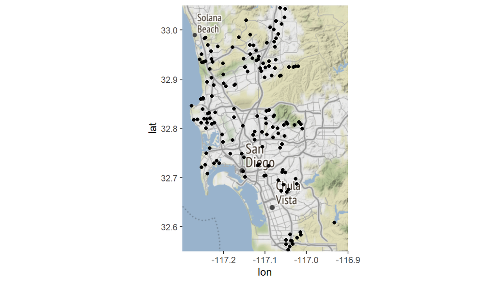

4. [2 pts] There are 9 NAs in `sites$cl2_total`. Why?
- Because there’re 9 sites that exist in `sites_ll$site_ID` but not `water_testing$source`
5. [2 pts] Write your own code that creates a new variable called `sites_sub` that is just like `sites`, but has the 9 sample sites with `NA` values for `cl2_total` removed.

```r
sites_sub <- sites$cl2_total[!is.na(sites$cl2_total)]
```

6. [1 pts] What is the coordinate reference system for the tract data?

```
## CRS arguments:
##  +proj=lcc +lat_1=33.88333333333333 +lat_2=32.78333333333333
## +lat_0=32.16666666666666 +lon_0=-116.25 +x_0=2000000.000101601
## +y_0=500000.0001016002 +datum=NAD83 +units=us-ft +no_defs +ellps=GRS80
## +towgs84=0,0,0
```

7. [1 pts] What is the name of the census tract with the lowest median household income? Highest?
- Name of census tract with lowest median income: 33.05
- Name of census tract with highest median income: 215